# 第4回 線形回帰の評価プロトコルを実装し、結果を解釈する

## 赤いほど遠い

7節 ② 色の差の式●●●●○

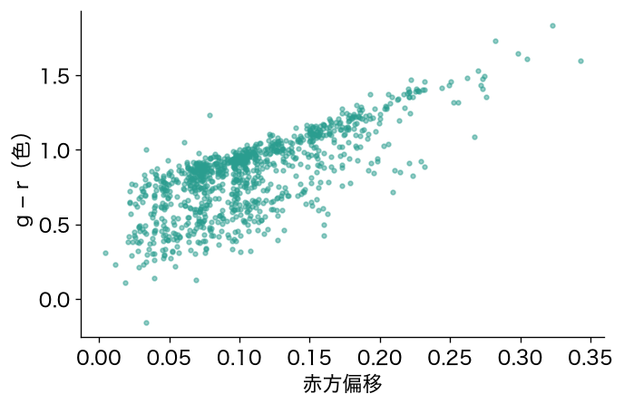

- g − rの係数は+0.256。ほかが同じなら、赤いほど遠い
- 色の差の式なら、係数がそのまま天文学の言葉で読める

## 重要：係数の意味は列で変わる

7節 ② 色の差の式●●●●●

係数は「ほかの列を同じにしたら」の値。一緒に入れた列が変われば、同じrでも係数の意味が変わる。

## お手本：rの係数は揺れるか

7節 ③ 揺れが消える●○

```python
coefs_c = []
for s in range(20):
    coefs_c.append(r_coef(colors, s))
print(round(min(coefs_c), 3), round(max(coefs_c), 3))
```

```
0.016 0.02
```

- 6節の`r_coef`に、色の差の列を渡すだけ

## 揺れが消えた

7節 ③ 揺れが消える●●

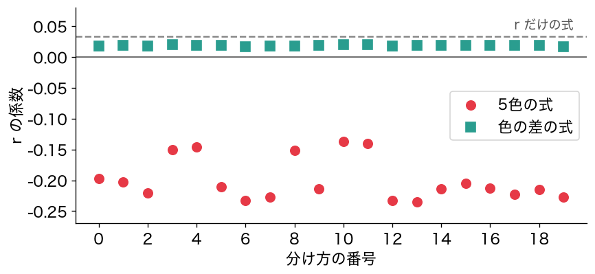

- 色の差の式では、rの係数は20回とも+0.016〜+0.020
- 相関の強い列を意味の違う列に作り直すと、多重共線性が消え、係数が読める

## TODO③：rと組む色を替える

7節 ④ 組む色●

```python
# TODO: ['u', 'r'] を ['r', 'i'] に替えて実行する
cols_x = ['u', 'r']
coefs_x = []
for s in range(20):
    coefs_x.append(r_coef(cols_x, s))
print(round(min(coefs_x), 3), round(max(coefs_x), 3))
```

- uとrの相関は0.758。rと相関の強いiは0.988
- 予想：rをiと組ませると、rの係数の揺れはどうなる？

## ここまでで分かったこと

7節 ⑤ 分かったこと●

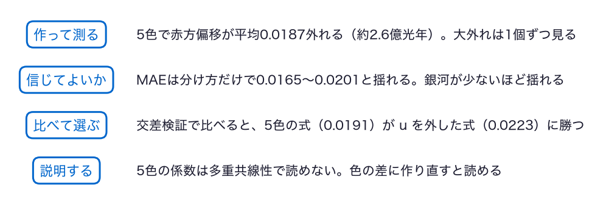

- 4つの段がそろい、今日の問いに答えられる

## ノートへ：6・7節

7節 ⑥ ノートへ●

- 6・7節のセルを上から実行し、スライドと同じ数が出るか確かめる
- TODO③：予想を書く → `['u', 'r']`を`['r', 'i']`に替えて実行 → 予想と比べる

動画の人は、ここで一時停止。

## 答え合わせ：TODO③

7節 ⑦ 答え合わせ●○

```
u と r  -0.016 -0.012
r と i  0.149 0.438
```

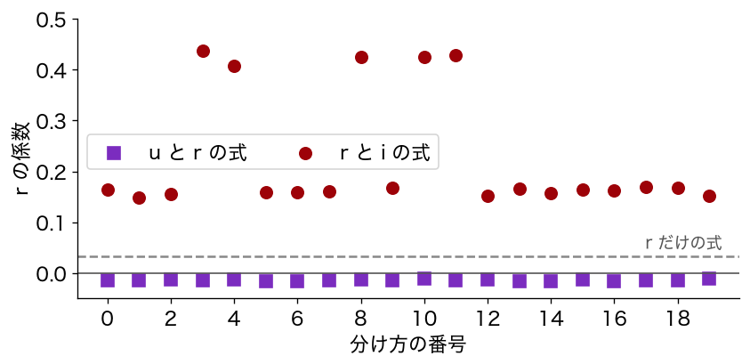

- uと組むと−0.016〜−0.012。iと組むと0.149〜0.438

## 似た2色は、手柄を分けられない

7節 ⑦ 答え合わせ●●

- rとiは、ほとんど同じことを言う。2色の式でも、係数は揺れる
- 相関の弱いuと組めば、係数は落ち着く
- 列の数ではなく、列どうしの相関が係数を揺らす

## 答え：約2.7億光年の外れで分かる

7節 ⑧ 答え●

- 5色だけで、赤方偏移は交差検証で平均0.0191の外れ（約2.7億光年）
- 14億光年ほど先の銀河まで、分光せずに見積もれる
- 係数は、色の差とrで作り直すと読める（赤いほど遠い）

## まだ言えないこと

7節 ⑨ まだ言えないこと●

- 遠い銀河ほど大きく外れる：直線の式で表しきれない関係がありそう
- 列を増やすと：二乗などを足せば当たるかもしれないが、似た列も増える
- 1個の銀河：この銀河が遠いと出た理由を、色ごとに言えるか

# まとめ

## 今日の道筋を振り返る

11 振り返る●○○○○

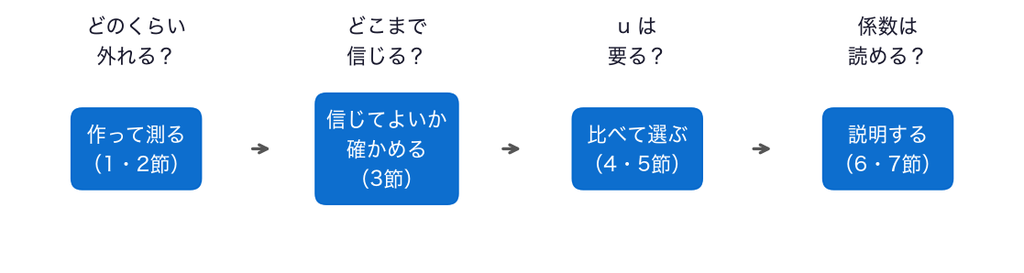

- 4つの段で、距離の当たりを確かめ、係数を読める形にした

## 今日持ち帰る1文

11 振り返る●●○○○

写真の色だけで、銀河までの距離はかなり当たる。ただし、その成績は交差検証で確かめる。相関の強い列を一緒に入れると（多重共線性）、予測は良くても係数は読めない。

## 重要概念：交差検証とリスト

11 振り返る●●●○○

統計：1回の分け方の数は揺れる。だから、全部の行を1度ずつテストに回し、外れ（今日はMAE）を平均する。2つの式は、同じ組どうしで比べる。

Python：くり返しの結果は、空のリストを作り、`for`の中で`append`して1つずつためる。

## 交差検証で見つけ、相関で確かめる

11 振り返る●●●●○

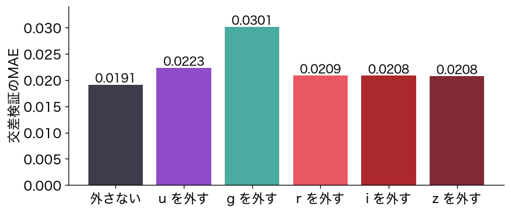

- r・i・zは、どれを外してもMAEがほとんど変わらない
- 相関はrとiで0.988、iとzで0.993。多重共線性を疑う

## 今日の要点

11 振り返る●●●●●

- 相関の強い列を一緒に入れると、予測は良くても係数は読めない（多重共線性）
- 係数は「ほかの列を同じにしたまま、その列を1増やしたときの変化」
- MAEは平均の外れ。大外れは1個ずつ見る。データが少ないほど揺れる

## 課題の出し方

12 このあと●○○

- 今日の重要概念は、統計の交差検証と、Pythonのリストにためる
- 2つを1枚ずつ絵にし、2枚をLACSに提出（＝出席。期限なし）
- 手描きの写真でも、描画アプリでもよい。上手でなくてよい

## 次回の問い

12 このあと●●○

- 今日は、5色を色の差に作り直して、係数を読める式にした
- でも、いつも作り直し方が分かるとは限らない
- 列がたくさんあるときに、当たりを保ちながら、係数を落ち着かせられるか

## このあと：課題へ

12 このあと●●●

- ノートの最後の「課題（提出）」を開く
- 絵を描き終えたら、このあとの「解答」で、絵の例と見比べる

# ここから先は解答

## 課題のあとで見る

- ここから先は、課題の絵を描き終えてから見る
- 絵の例を2つ見せる。上手さではなく、考えが伝わるかを見比べる

## 絵の例：交差検証

- データを5切れのケーキに分け、1切れずつ順に味見役に回す
- 全部の切れが1度ずつ味見されるので、たまたまおいしい1切れに当たっても偏らない
- 2つのケーキを比べるときは、同じ切り方どうしで味見する

## 絵の例：リストにためる

- 空の箱を1つ用意し、流れてくる結果を1つずつ、箱の後ろに入れていく
- 20回くり返すと、箱に20個がたまる
- 箱の中身を並べると、いちばん小さい・大きい・平均が分かる

# 発展（任意）

## 1個の銀河を説明する

$$\hat{y} = \hat{y}_{\text{平均的な銀河}} + \sum_j b_j (x_j - \bar{x}_j)$$

- 平均的な銀河：どの列も1,000個の平均$\bar{x}_j$の値をもつ銀河
- $b_j(x_j - \bar{x}_j)$が、列$j$がこの銀河の予測を平均よりどれだけ押し上げたか

## 平均的な銀河 + 寄与

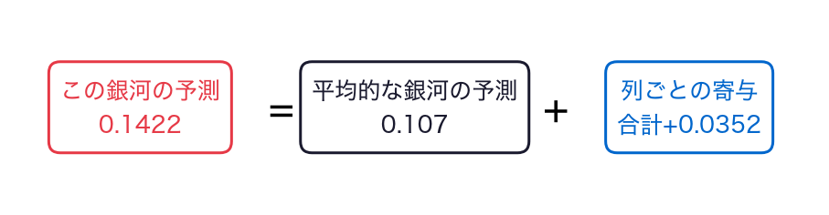

- 8番目の銀河（番号7）の予測は、平均的な銀河より0.035ほど大きい

## お手本：8番目の銀河の内訳

```python
avg = m_c.predict(df[colors]).mean()   # 平均的な銀河の予測
k = 7                                  # 銀河の番号（0から数える）
gal = df[colors].iloc[k]
push = coef_c * (gal - df[colors].mean())   # 列ごとの寄与
print(round(avg, 4), round(avg + push.sum(), 4), df['赤方偏移'][k])
print(push.round(4))
```

```
0.107 0.1422 0.1514
u-g   -0.0213
g-r    0.0717
r-i    0.0014
i-z   -0.0140
r     -0.0026
```

- `df[colors].iloc[k]`：`colors`の列だけの表から、`k`行目を取り出す

## お手本：寄与を棒で描く

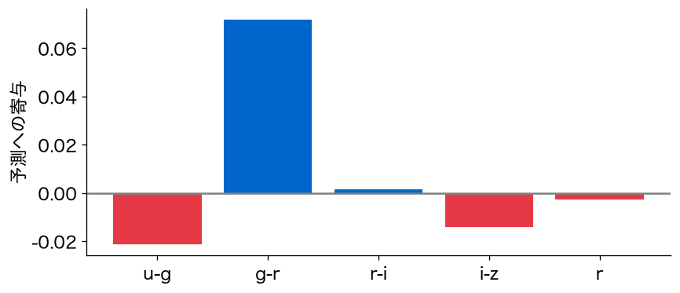

```python
plt.bar(push.index, push)
plt.axhline(0, color='gray')
plt.ylabel('予測への寄与')
plt.show()
```

## 赤いから遠い

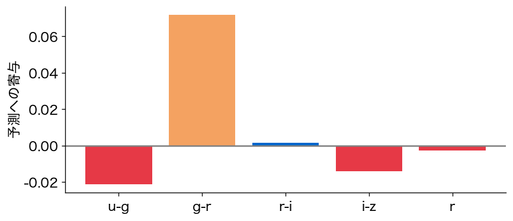

- 予測0.1422、実際0.1514。いちばん押し上げているのはg − r（+0.0717）
- この銀河は平均より赤い。式は「赤いから遠い」と判断した

## お手本：番号4の銀河

```python
k = 4
gal = df[colors].iloc[k]
push = coef_c * (gal - df[colors].mean())
print(round(avg + push.sum(), 4), df['赤方偏移'][k])
print(push.round(4))
```

```
0.0823 0.03825
u-g    0.0329
g-r   -0.1366
r-i   -0.0033
i-z    0.0702
r      0.0121
```

- 番号4の銀河は、実際の赤方偏移が0.038の、近い銀河

## 青いから近い

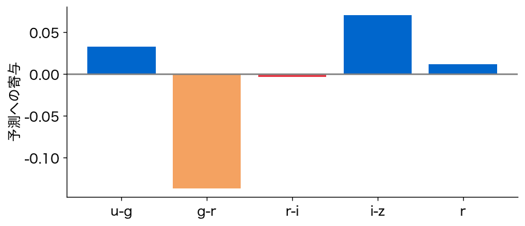

- 予測0.0823、実際0.03825。g − rが−0.1366と、大きく押し下げている
- 平均よりずっと青い銀河。式は「青いから近い」と判断した

## i − zが押し上げて外れた

- i − zは+0.0702と押し上げ、予測は実際より遠めに外れた
- 青い銀河は、星を盛んに作っている銀河に多く、光の分布が違う
- こうした銀河は、5色の直線の式では当てにくい

## 色の二乗を足す

- 遠い銀河ほど、式は近めに当てていた。関係がまっすぐでないのかもしれない
- 色の差の二乗の列を足すと、線形回帰の式でも曲がった関係を表せる

## お手本：二乗の列を足す

```python
squares = []
for c in ['u-g', 'g-r', 'r-i', 'i-z']:
    df[c + 'の二乗'] = df[c] ** 2
    squares.append(c + 'の二乗')
print(round(np.mean(cv_mae(colors)), 4))
print(round(np.mean(cv_mae(colors + squares)), 4))
```

```
0.0191
0.0182
```

## 0.0191から0.0182へ

- 二乗を足すと、交差検証のMAEは0.0191から0.0182に下がる
- ただ、列は5本から9本に増え、似た列も増えた

## 似た列を1つの数で：VIF

$$\text{VIF}_j = \frac{1}{1 - R_j^2}$$

- 列$j$を、ほかの全部の列で当てた決定係数が$R_j^2$
- 分散拡大係数（VIF）。係数の揺れが、似た列のせいで何倍に膨らむか

## お手本：VIFの関数

```python
def vif(cols):
    out = {}
    for c in cols:
        others = []
        for o in cols:
            if o != c:
                others.append(o)
        m_v = LinearRegression().fit(df[others], df[c])
        r2 = m_v.score(df[others], df[c])
        out[c] = round(1 / (1 - r2), 1)
    return pd.Series(out)

print(vif(bands))
print(vif(colors))
```

## 5色は最大228.8、色の差は最大4.8

```
u     18.7
g     77.5
r    123.3
i    228.8
z    195.3
u-g    3.2
g-r    4.8
r-i    1.7
i-z    2.9
r      1.1
```

- 色の差に作り直すと、VIFは1.1〜4.8まで下がる

## VIFは目安

- VIFは、どの列が似た列を持っているかを見つける目安
- 列をどう作り直すかは、VIFだけでは決まらない。データの意味から考える

## 試すなら

- 二乗を足した9本の列`colors + squares`でもVIFを出してみる
- 二乗の列と、その元の列のVIFがどれくらい大きいかを確かめる

## MAEでなくRMSEで測ると？

- 二乗の列を足すと、交差検証のMAEは0.0191から0.0182に下がった
- 外れの物差しを替えても、同じ結論になるか

## 大外れを重く数える：RMSE

$$\text{RMSE} = \sqrt{\frac{1}{n}\sum_{i=1}^{n} (y_i - \hat{y}_i)^2}$$

- 外れを二乗して平均し、平方根で赤方偏移の単位に戻す
- 二乗平均平方根誤差（RMSE）。大きく外れた銀河ほど重く数える

## お手本：RMSEの交差検証

```python
def cv_rmse(cols):
    rmses_k = []
    for k in range(5):
        tr_k = df[df['組'] != k]      # 組k以外で訓練
        te_k = df[df['組'] == k]      # 組kでテスト
        m_k = LinearRegression().fit(tr_k[cols], tr_k['赤方偏移'])
        pred_k = m_k.predict(te_k[cols])
        err2 = (te_k['赤方偏移'] - pred_k) ** 2
        rmses_k.append(np.sqrt(err2.mean()))
    return rmses_k
```

- `cv_mae`と比べて、変わったのは外れを測る2行だけ
- `np.sqrt`は平方根

## お手本：RMSEで比べ直す

```python
cols_sq = colors + squares
r5 = cv_rmse(bands)
r4 = cv_rmse(no_u)
r_c = cv_rmse(colors)
r_sq = cv_rmse(cols_sq)
for r in [r5, r4, r_c, r_sq]:
    print(np.round(r, 4), round(np.mean(r), 4))
```

```
[0.0284 0.0234 0.0341 0.0254 0.0236] 0.027
[0.0289 0.026  0.0519 0.0304 0.0283] 0.0331
[0.0284 0.0234 0.0341 0.0254 0.0236] 0.027
[0.0247 0.0209 0.0926 0.0225 0.0223] 0.0366
```

- 上から、5色・uを外す・色の差・二乗を足した式

## uの結論はRMSEでも同じ

- 5色の式は0.027、uを外すと0.0331
- 5つの組すべてで、5色の式が勝つ

## 二乗の列は、RMSEでは悪くなる

- MAEでは0.0191から0.0182に良くなった
- RMSEでは0.027から0.0366に悪くなる
- 組2だけ、RMSEが0.0926に跳ね上がる

## お手本：組2で外れた銀河

```python
tr_2 = df[df['組'] != 2]      # 組2以外で訓練
te_2 = df[df['組'] == 2]      # 組2でテスト
m_2 = LinearRegression().fit(tr_2[cols_sq], tr_2['赤方偏移'])
pred_2 = m_2.predict(te_2[cols_sq])
err_2 = np.abs(te_2['赤方偏移'] - pred_2)
print(err_2.sort_values().tail(3).round(3))
```

```
462    0.069
302    0.166
92     1.259
```

- 92番の銀河だけが、1.259も外れた

## お手本：92番の色

```python
print(df.loc[92, colors].round(2))     # 92番の銀河
print(df[colors].median().round(2))    # 1,000個の中央値
```

```
u-g    -0.63
g-r     1.73
r-i    -1.96
i-z     0.97
r      15.45
u-g     1.74
g-r     0.86
r-i     0.40
i-z     0.30
r      17.14
```

- `df.loc[92, colors]`：番号92の行の、`colors`の列

## 92番は、ほかに無い色

- r − iが−1.96。1,000個の中央値は0.4
- rだけが、iより2等級近く明るい。測り損ねかもしれない
- 二乗の式は、見たことのない色の銀河で、大きく外れることがある

## 物差しで結論が変わったら

- MAEは平均の外れ。1個の大外れは、平均にならされる
- RMSEは、1個の大外れに大きく引っぱられる
- 結論が分かれたら、大外れを1個ずつ見る（2節と同じ）

## おわり

- お疲れさまでした